# LAB5

2/14/2019

## Outline

R package `statnet` : focus on package `ergm`

- `summary` network statistics
- `ergm` model fitting and interpretation:
- `simulate` network simulations based on specified model.
- `gof`, `mcmc.diagnostics`: Goodness of fit and MCMC diagnostics

## `statnet`

The analytic framework is based on **Exponential family Random Graph Models (ergm)**.

**statnet** provides a comprehensive framework for **ergm-based** network modeling, including tools for:

- model estimation
- model-based network simulation
- network visualization
- model evaluation

Powered by **Markov chain Monte Carlo (MCMC)** algorithm.

## `statnet`

- Official website (handbook): http://statnet.org/
- Tutorial: https://statnet.org/trac/raw-attachment/wiki/Sunbelt2016/ergm_tutorial.html
- **Explore the official websites to find more info**

## Preparation

```r
#install.packages("statnet")
library(statnet)
library(dplyr)
```

## `summary` the network statistics

## Dataset

florentine: Florentine Family Marriage and Business Ties Data

```r
data(package="ergm") #see all available dataset in the package
data(florentine) # load flomarriage and flobusiness data
flomarriage # see the details of the network
```

```
##  Network attributes:
##   vertices = 16
##   directed = FALSE
##   hyper = FALSE
##   loops = FALSE
##   multiple = FALSE
##   bipartite = FALSE
##   total edges= 20
##     missing edges= 0
##     non-missing edges= 20
##
##  Vertex attribute names:
##     priorates totalties vertex.names wealth
##
## No edge attributes
```

```r
class(flomarriage)
```

```
## [1] "network"
```

```r
summary(flomarriage)
```

```
## Network attributes:
##   vertices = 16
##   directed = FALSE
##   hyper = FALSE
##   loops = FALSE
##   multiple = FALSE
##   bipartite = FALSE
##  total edges = 20
##    missing edges = 0
##    non-missing edges = 20
##  density = 0.1666667
##
## Vertex attributes:
##
##  priorates:
##    numeric valued attribute
##    attribute summary:
##    Min. 1st Qu.  Median    Mean 3rd Qu.    Max.
##    0.00    0.00   21.50   25.94   44.75   74.00
##
##  totalties:
##    numeric valued attribute
##    attribute summary:
##    Min. 1st Qu.  Median    Mean 3rd Qu.    Max.
##    1.00    4.75    9.00   13.88   15.00   54.00
##   vertex.names:
##    character valued attribute
##    16 valid vertex names
##
##  wealth:
##    numeric valued attribute
##    attribute summary:
##    Min. 1st Qu.  Median    Mean 3rd Qu.    Max.
##    3.00   17.50   39.00   42.56   48.25  146.00
##
## No edge attributes
##
## Network edgelist matrix:
##       [,1] [,2]
##  [1,]    1    9
##  [2,]    2    6
##  [3,]    2    7
##  [4,]    2    9
##  [5,]    3    5
##  [6,]    3    9
##  [7,]    4    7
##  [8,]    4   11
##  [9,]    4   15
## [10,]    5   11
## [11,]    5   15
## [12,]    7    8
## [13,]    7   16
## [14,]    9   13
## [15,]    9   14
## [16,]    9   16
## [17,]   10   14
## [18,]   11   15
## [19,]   13   15
## [20,]   13   16
```

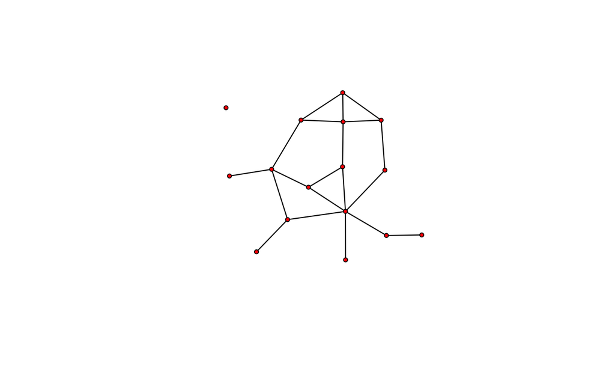

```r
set.seed(1)
plot(flomarriage)
```

## `summary`

`summary(network-object~ergm-terms)`: provide the statistics of network

```r
summary(flomarriage~edges+triangle+kstar(1:3)+degree(0:5))
```

```
##    edges triangle   kstar1   kstar2   kstar3  degree0  degree1  degree2
##       20        3       40       47       34        1        4        2
##  degree3  degree4  degree5
##        6        2        0
```

## directed networks

```r
data(samplk)
samplk3
```

```
##  Network attributes:
##   vertices = 18
##   directed = TRUE
##   hyper = FALSE
##   loops = FALSE
##   multiple = FALSE
##   bipartite = FALSE
##   total edges= 56
##     missing edges= 0
##     non-missing edges= 56
##
##  Vertex attribute names:
##     cloisterville group vertex.names
##
## No edge attributes
```

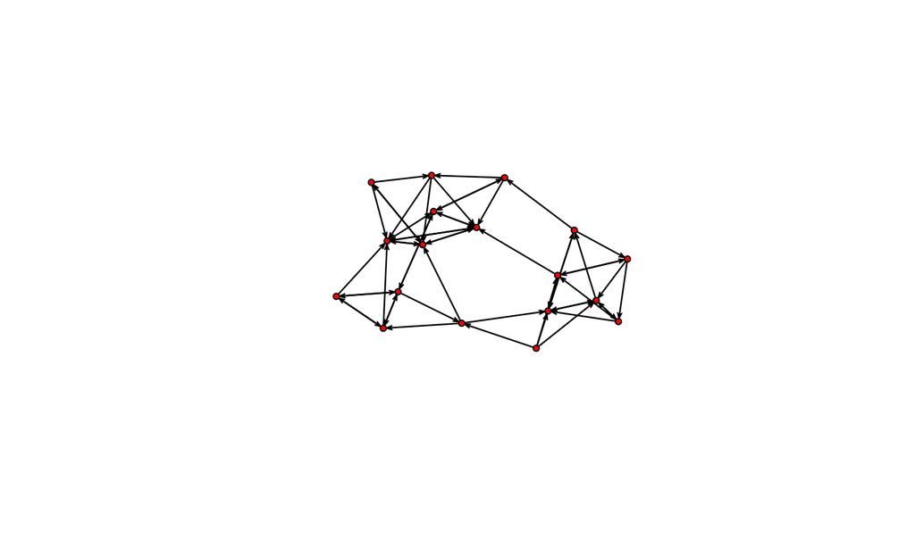

```r
set.seed(1)
plot(samplk3)
```

## directed networks

`idegree` and `odegree`.

```r
summary(samplk3~idegree(1:3)+odegree(c(2,4))) #indegree and outdegree
```

```
## idegree1 idegree2 idegree3 odegree2 odegree4
##        1        7        2        0        2
```

## `ergm` fit ergm model

## ERGM

The general form: \(P(g=G)=\frac{exp(\theta'T(G))}{c(\theta)}\)

log-odds of a single edge between node \(i\) and \(j\): \(logit(Y)=\theta'T(G)\)

Similar as regression:

`glm(y~x)` – `ergm(graph~terms)` where `terms` are \(T(\cdot)\)

## `ergm` function.

- Input: formula [netowrk object (adjacency matrix)] ~ [ergm-terms]

```r
#Input
?ergm
class(flomarriage)
```

```
## [1] "network"
```

```r
ergm(flomarriage~edges)%>%summary()
```

```
## Starting maximum pseudolikelihood estimation (MPLE):
```

```
## Evaluating the predictor and response matrix.
```

```
## Maximizing the pseudolikelihood.
```

```
## Finished MPLE.
```

```
## Stopping at the initial estimate.
```

```
## Evaluating log-likelihood at the estimate.
```

```
##
## ==========================
## Summary of model fit
## ==========================
##
## Formula:   flomarriage ~ edges
##
## Iterations:  5 out of 20
##
## Monte Carlo MLE Results:
##       Estimate Std. Error MCMC % z value Pr(>|z|)
## edges  -1.6094     0.2449      0  -6.571   <1e-04 ***
## ---
## Signif. codes:  0 '***' 0.001 '**' 0.01 '*' 0.05 '.' 0.1 ' ' 1
##
##      Null Deviance: 166.4  on 120  degrees of freedom
##  Residual Deviance: 108.1  on 119  degrees of freedom
##
## AIC: 110.1    BIC: 112.9    (Smaller is better.)
```

```r
mat=as.sociomatrix(flomarriage)
ergm(mat~edges)%>%summary()
```

```
## Starting maximum pseudolikelihood estimation (MPLE):
## Evaluating the predictor and response matrix.
## Maximizing the pseudolikelihood.
## Finished MPLE.
## Stopping at the initial estimate.
## Evaluating log-likelihood at the estimate.
```

```
##
## ==========================
## Summary of model fit
## ==========================
##
## Formula:   mat ~ edges
##
## Iterations:  5 out of 20
##
## Monte Carlo MLE Results:
##       Estimate Std. Error MCMC % z value Pr(>|z|)
## edges  -1.6094     0.1732      0  -9.292   <1e-04 ***
## ---
## Signif. codes:  0 '***' 0.001 '**' 0.01 '*' 0.05 '.' 0.1 ' ' 1
##
##      Null Deviance: 332.7  on 240  degrees of freedom
##  Residual Deviance: 216.3  on 239  degrees of freedom
##
## AIC: 218.3    BIC: 221.8    (Smaller is better.)
```